# Prosper Loans Data Visualization

# Observations :

> Graphs show a slight positive relation between loan amount and borrowes income, also distinct vertical lines appears in the graphs and it can be explained by the presencse of certain popular packages(5K intervals).

## Visualization 19:

## Relation between Loan amounts and borrowers monthly payments

[figure not shown]

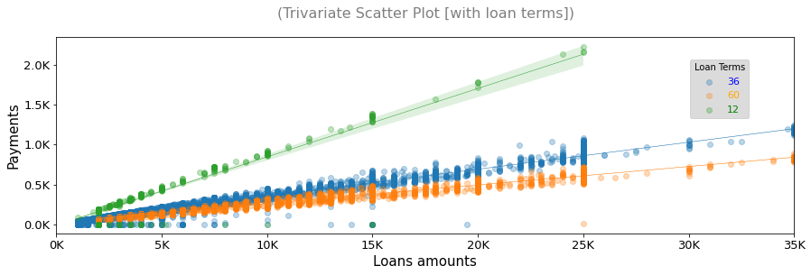

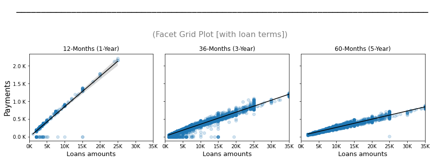

```python
plt.figure(figsize=(14,4))
plt.subplot(1,2,1)
sb.regplot(data= sample, y='payment', x='amount', scatter_kws={'alpha': 0.05},line_kws={'color': 'r', 'lw':2})
plt.xlim(0,35500)
plt.draw()
locs, labels =plt.xticks()
labels = [str(round(float(x.get_text())/1000))+ 'K' for x in labels]
plt.xticks(locs, labels, fontsize=13)
plt.ylim(0,2000)
plt.draw()
locs, labels =plt.yticks()
labels = [str(round(float(x.get_text())/1000,1))+ 'K' for x in labels]
plt.yticks(locs, labels, fontsize=13)
plt.ylabel('Payments', size=15)
plt.xlabel('Loans amounts', size=15)
plt.suptitle('Relation between Loan amounts and incomes', size=20, fontweight='bold', va='bottom')
plt.title('(Bivariate Scatter Plot showing regression)', size=16, color='grey')
plt.text(-0.1,-0.3, '_'*82, transform= plt.gca().transAxes, color='black', fontsize=20)

plt.subplot(1,2,2)
plt.title('(Kernel density Plot showing pattern)', fontsize=17, color='grey')
sb.kdeplot(data= sample, y='payment', x='amount', n_levels=15, shade=True,cmap='coolwarm', cbar=True)
plt.xlim(0,30000)
plt.ylim(0,2000)
plt.draw()
locs, labels =plt.yticks()
labels = [str(round(float(x.get_text())/1000,1))+ 'K' for x in labels]
plt.yticks(locs, labels, fontsize=13)
locs, labels =plt.xticks()
labels = [str(round(float(x.get_text())/1000))+ 'K' for x in labels]
plt.xticks(locs, labels, fontsize=13)
plt.ylabel('Incomes', size=15)
plt.xlabel('Loans amounts', size=15)
plt.title('(Kernel Density Plot showing patterns)', size=16, color='grey')
plt.show()

g=sb.FacetGrid(data=sample, hue='term',hue_order=df.term.value_counts().index)
g.map(sb.regplot,'amount', 'payment', scatter_kws={'alpha': 0.3},line_kws={'lw':0.5})
x_ticks= np.arange(0,35001,5000)
g.set(xticks=x_ticks)
g.set_xticklabels([str(round(float(x/1000)))+'K' for x in x_ticks], size=13)
y_ticks= np.arange(0,2001,500)
g.set(yticks=y_ticks)
g.set_yticklabels([str(round(float(x/1000),1))+'K' for x in y_ticks], size=13)
g.set_ylabels('Payments', size=15)
g.set_xlabels('Loans amounts', size=15)
g.despine(top=False, right=False)
plt.gcf().set_size_inches(16, 4)
g.add_legend(bbox_to_anchor=(0.9,0.75),
           bbox_transform=plt.gcf().transFigure,
           title='Loan Terms',
           prop={'size':11},
           labelcolor=['blue', 'orange','green'],
           frameon=True,
           facecolor='lightgray')
plt.text(0.3,1.1, '(Trivariate Scatter Plot [with loan terms])', transform= plt.gca().transAxes, color='grey', fontsize=16);


g= sb.FacetGrid(data=sample, col='term', height= 5, margin_titles=True, sharey=True, sharex=True)
g.map(sb.regplot ,'amount','payment', scatter_kws={'alpha':0.2}, line_kws={'color':'black','lw':1.5});
x_ticks= np.arange(0,35500,5000)
g.set(xticks=x_ticks)
g.set_xticklabels([str(round(float(x/1000)))+'K' for x in x_ticks])
y_ticks= np.arange(0,2001,500)
g.set(yticks=y_ticks)
g.set_yticklabels([str(round(float(x/1000),1))+' K' for x in y_ticks])
g.set_ylabels('Payments', size=15)
g.set_xlabels('Loans amounts', size=13)
g.axes[0,0].set_title('12-Months (1-Year)')
g.axes[0,1].set_title('36-Months (3-Year)')
g.axes[0,2].set_title('60-Months (5-Year)')
plt.gcf().set_size_inches(12, 3)
g.despine(top=False, right=False)
plt.text(-1.2,1.2, '(Facet Grid Plot [with loan terms])', transform= plt.gca().transAxes, color='grey', fontsize=16)
plt.text(-2.3,1.5, '_'*82, transform= plt.gca().transAxes, color='black', fontsize=20)
plt.show()
```

# Notes :

> The Scatter Plots is performed on (25% of data) and with (95% transperancy) to ensure the figure clarity.

# Observations :

> Graphs show a positive relation between loan amount and borrowes monthly payments. Each line of the three distinct lines belong to a certain (term), the longer the term period the less the borrower pay, wich make sense.